# tRowel vignette

##### 3:3 loamRanger

`loamRanger` plots the composition of soil/sediments by the percent representation of clay, silt, and sand. There are 11 arguments. The bolded arguments are required to use the function:

1. *dirtdata* Dataframe where the user pulls the texture data from
2. *depth* The name of column containing starting depth data.
3. *sand* The name of column containing sand composition data.
4. *silt* The name of column containing silt composition data. Clay will be calculated by subtracting silt and sand percentages from 100.
5. *sandcolor* Type the color to represent sand in plot.
6. *siltcolor* Type the color to represent silt in plot.
7. *claycolor* Type the color to represent clay in plot.
8. depth_intervals Numeric. Interval for plotting depths. This default value of this argument is 10.
9. mindepth Numeric. Starting depth for the plot. The default value is 0.
10. maxdepth Numeric. Sets maximum depth for the plot. Default is NA.
11. title Character. Title to be added to the plot.

##### Example of loamRanger

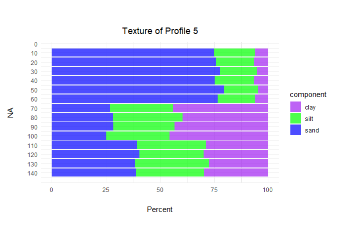

```r
#filter for one profile
testPitP5 <- dplyr::filter(testPit, ProfileID == "Profile_5")

loamP5 <- loamRanger(testPitP5, depth = "Depth_cm_Start", sand = "Sand_pct", silt = "Silt_pct", sandcolor = "blue", siltcolor = "green", claycolor = "purple", mindepth=0, title = "Texture of Profile 5")

loamP5
```

##### 3:4 groundTruth

groundTruth prepares your soil/sediment profile picture for use in paleoPanel. This function saves your soil/sediment pic as a ggplot object, so you can combine it with other plots in paleoPlot.

1. *imagefile* Name of file containing a picture of the soils/sediment
2. imageformat File format of imagefile. Should be either png or jpg. Default is png.
3. *width* Numeric. Width for scaling the image for ggplot plotting
4. *height* Numeric. Height for scaling the image for ggplot plotting
5. *WHratio* the width-to-height ratio of your image. tRowel recommends you look up the pixel width and height of the actual image description

##### Example of groundTruth

```r
#download example image
file_path <- system.file("extdata", "groundTruth.png", package = "tRowel")

#save to figure name
soilpic <- groundTruth(file_path, imageformat = "png", width = 10, height = 10, WHratio = 1)
```

##### 3:5 paleoPanel

paleoPanel plots multiple existing figures/plots to create a multi-figure panel plot.

1. *…* This argument provides unlimited space to upload as many figure/plot names as needed. They plot in the order that they are uploaded.
2. profile Option to input the figure name created in groundTruth to add a stratigraphic photo to the front of the panel figure
3. rows Numeric. Number of rows for the panel figure, defaults to 1 row.
4. *cols* Numeric. Number of columns to format the panel figure. If you have 1 in the rows argument, make sure this is equal to the number of plots inputted
5. label_angle Numeric. The angle of X axis labels
6. border Boolean. If TRUE, the panel figure will have a border. Its default is FALSE
7. bordercolor Character. If border = TRUE, type the color of the border. Default is darkgrey.
8. marginsize Numeric. Adjusts the margin size between the figures
9. plotwidths Numeric Vector. Assists in adjusting the spacing when the profile argument (picture of profile from groundTruth) is not NA. Input two numbers (i.e., plotwidths = c(1,5)), the first number reflects the width of the profile argument, and the second number reflects the width of panel figures.

##### Examples of paleoPanel:

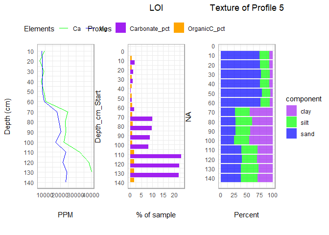

```r
#No groundTruth image:
paleoPanel(terraP5,buriedP5,loamP5,cols = 3,border=TRUE)
```

```
## ℹ Adding new coordinate system, which will replace the existing one.
```

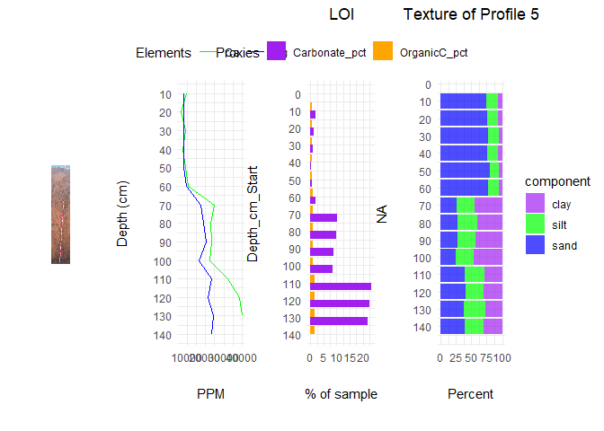

```r
#With groundTruth
paleoPanel(terraP5,buriedP5,loamP5,cols = 3,profile = soilpic,plotwidths = c(1,3))
```

### Helpful tips for making figures

1. You can control the figure size/dimensions when you set up your opts_chunk or when you hit Export (export > save image > adjust width/height > update preview). If your preview of your figure looks distorted, you need to adjust your RStudio setting or just wait to export them.
2. These figures function as ggplots. So, if you want to add something (i.e. a new theme), you’d type your figure name and then use plus signs like you would in ggplot2 (for more information see ggplot2 package)

## 4. Stats with figures functions

##### 4:1 clastCluster

clastCluster statistically clusters (using Gower’s or Euclidean) and then graphically display soil/sediment data as a profile. Before completing the cluster analysis, the function will display an average silhouette plot (the ideal number of clusters will have the highest value). The user will manually type the number of clusters in the console and hit enter. next, the function will return any plots the user picked in the arguments (ordination or plot [profile plot]) and return a list containing the data and plots.This data can be used to apply elevation points to the plot in terraceWrangler.

##### Example of clastCluster

```r
#Example using Euclidean distance and PCA
library(dplyr)
testPitM <- testPit_withMun
testPitM <- select(testPitM, -c(Munsell) )

EuclidExample <- clastCluster(dirtdata = testPitM, distance = "E", depthStart = "Depth_cm_Start", depthEnd = "Depth_cm_End",
  profile = "ProfileID", ordination = TRUE, plot = TRUE, maxDepth = 150, depthticks = 10)

4#For the number of clusters to select

EuclidExample

#Example using Gower's distance and PCoA
# testPit2 <- testPit
# testPit2 <- select(testPit2, -c(SampleID) )
GowerExample <- clastCluster(dirtdata = testPitM, distance = "G",depthStart = "Depth_cm_Start", depthEnd = "Depth_cm_End",
   minK = 2, maxK=8, profile = "ProfileID", ordination = TRUE, plot = TRUE, plotTitle="Cluster Analysis of Arroyo Profiles",
   maxDepth = 150, depthticks = 10)

4#For the number of clusters to select

GowerExample
```

Note that in this example, that we set `maxDepth = 150` even though our maximum in the `depthStart` in the data is 140. This is because data in our case for `depthStart` represent the starting depth of a sample zone and our sample zones are every 10 cm. Therefore we need to add 10 to our maximum depth range when plotting to include samples starting at 140 cm.

##### 4:2 terraceWrangler

terraceWrangler uses the returned data from clastCluster and replots it with elevation to show relief across a landscape. So, profiles must be entered in order from the original dirtdata used in clastCluster.

There are 10 arguments. The bolded arguments are required to run the function:

1. *clastData* Enter clastCluster data from the saved clastCluster list in environment
2. *elevData* Data frame. Name of the df containing Profile Name and Elevation columns
3. *surfaceElevM* Name of the column containing elevation (meters only) in elevData
4. *profileClast* Name of the profile ID column in clastData
5. *profileElev* Name of the profile ID column in elevData
6. depthticksM Numeric. The displayed numeric intervals of the depth axis, the default is 1 meter
7. clusterColors Character. Colors to be used in plotting. Default is random soil-like colors.
8. title Character. Title of plot
9. xLabel Character. Title of profile axis
10. yLabel Character. Title of depth axis, the default is “Depth (m)”

##### Example of terraceWrangler

*You must complete the clastCluster example above before running the terraceWrangler examples.*

```r
terraceWrangler(clastData = EuclidExample$data, elevData = testElevation,surfaceElevM = "surfaceElevM",profileClast = "ProfileID",profileElev = "ProfileID")
```